# CreditCardChurn

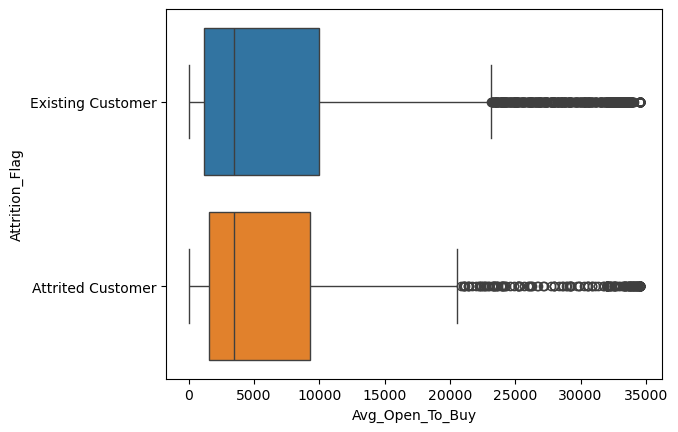

```python
sns.boxplot(data=df, x='Avg_Open_To_Buy', hue='Attrition_Flag', y='Attrition_Flag')
```

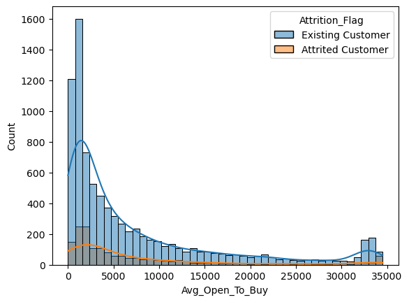

```python
sns.histplot(data=df, x='Avg_Open_To_Buy', hue='Attrition_Flag', kde=True)
```

- ***Avg_Open_To_Buy** has a **highly right skewed distribution** with the majority of customers having it **<= \$4000***

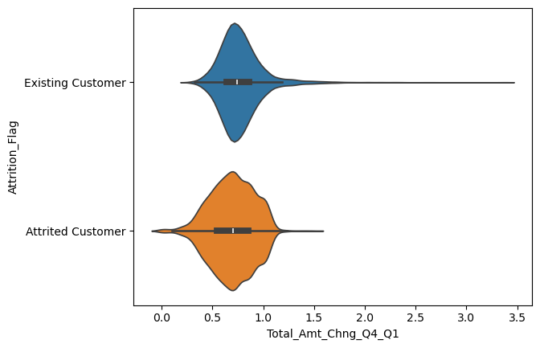

```python
sns.violinplot(data=df, x='Total_Amt_Chng_Q4_Q1', hue='Attrition_Flag', y='Attrition_Flag')
```

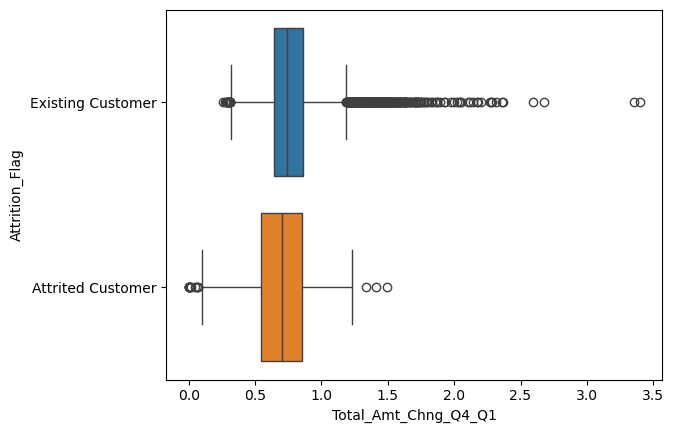

```python
sns.boxplot(data=df, x='Total_Amt_Chng_Q4_Q1', hue='Attrition_Flag', y='Attrition_Flag')
```

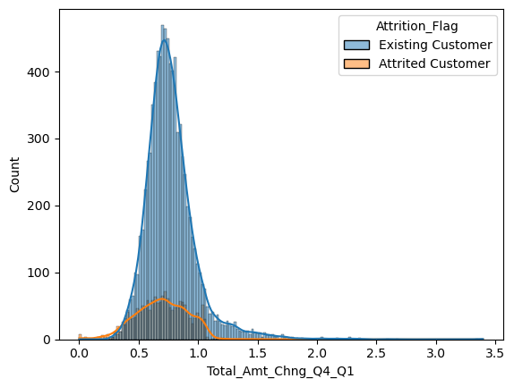

```python
sns.histplot(data=df, x='Total_Amt_Chng_Q4_Q1', hue='Attrition_Flag', kde=True)
```

- ***Total_Amt_Chng_Q4_Q1** is a **mostly normal distribution of for lower values***
- ***Total_Amt_Chng_Q4_Q1** has a very **high number of outliers for existing customers** indicating that **higher ratios** exist mostly for existing customers*

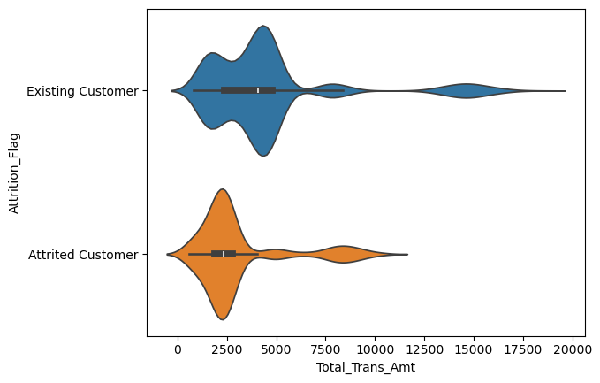

```python
sns.violinplot(data=df, x='Total_Trans_Amt', hue='Attrition_Flag', y='Attrition_Flag')
```

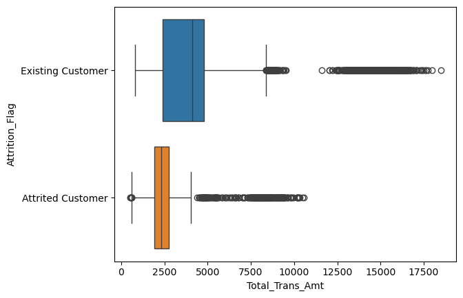

```python
sns.boxplot(data=df, x='Total_Trans_Amt', hue='Attrition_Flag', y='Attrition_Flag')
```

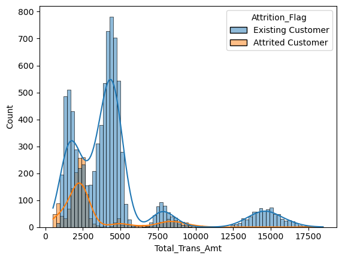

```python
sns.histplot(data=df, x='Total_Trans_Amt', hue='Attrition_Flag', kde=True)
```

- ***Total_Trans_Amt** shows a **multimodal distribution** for customers*
- *There are about* *4 clusters** seen for existing customers whereas **1 major cluster seen for attrited customers in and around \$2400***

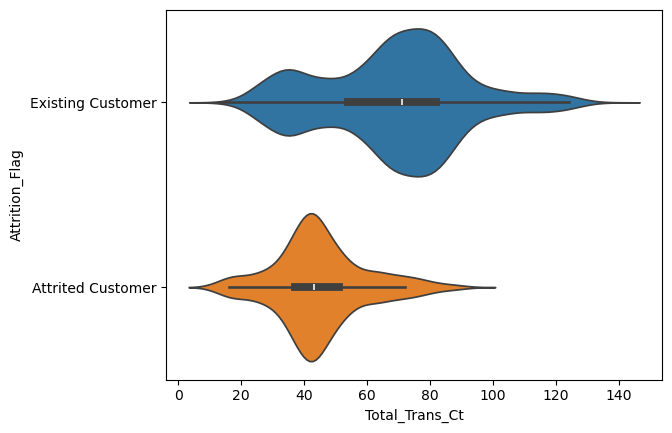

```python
sns.violinplot(data=df, x='Total_Trans_Ct', hue='Attrition_Flag', y='Attrition_Flag')
```

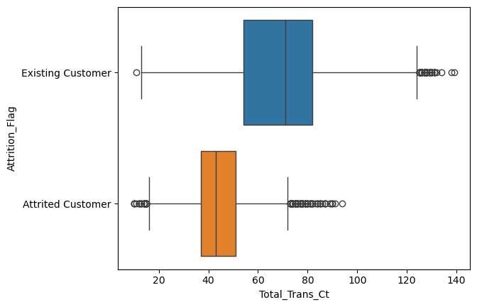

```python
sns.boxplot(data=df, x='Total_Trans_Ct', hue='Attrition_Flag', y='Attrition_Flag')
```

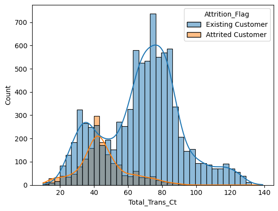

```python
sns.histplot(data=df, x='Total_Trans_Ct', hue='Attrition_Flag', kde=True)
```

- ***Total_Trans_Ct** shows **2 clusters for existing customers**. It also has a **higher median value around 70 for existing customers***
- ***Total_Trans_Ct** shows an **almost normal distribution** around the **median of about 42 for attrited customers***
- *There is a clear pattern that* *existing and attrited customers have almost clearly separated medians**.* *Lower Total_Trans_Ct** is shown **for attrited customers** compared to existing customers*

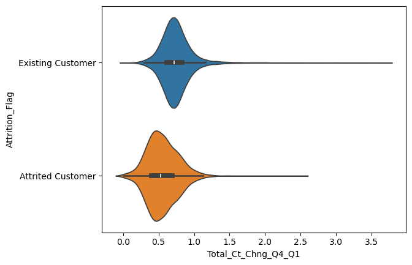

```python
sns.violinplot(data=df, x='Total_Ct_Chng_Q4_Q1', hue='Attrition_Flag', y='Attrition_Flag')
```

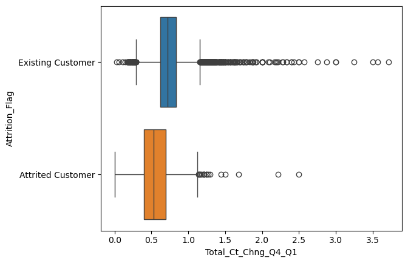

```python
sns.boxplot(data=df, x='Total_Ct_Chng_Q4_Q1', hue='Attrition_Flag', y='Attrition_Flag')
```

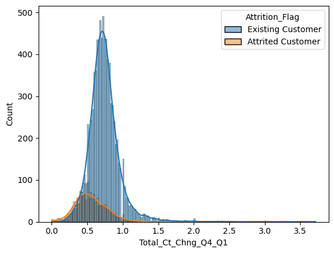

```python
sns.histplot(data=df, x='Total_Ct_Chng_Q4_Q1', hue='Attrition_Flag', kde=True)
```

- ***Total_Ct_Chng_Q4_Q1** has almost **normal distributions** for both classes of customers but **clearly separated medians** of around 0.5 for attrited and around 0.7 for existing customers*
- ***Total_Ct_Chng_Q4_Q1** has a **lot of outliers for existing customers** and **higher ratios almost always indicates existing customers***

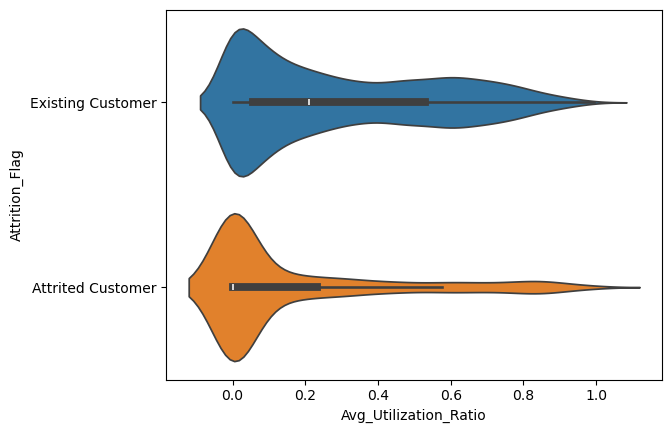

```python
sns.violinplot(data=df, x='Avg_Utilization_Ratio', hue='Attrition_Flag', y='Attrition_Flag')
```

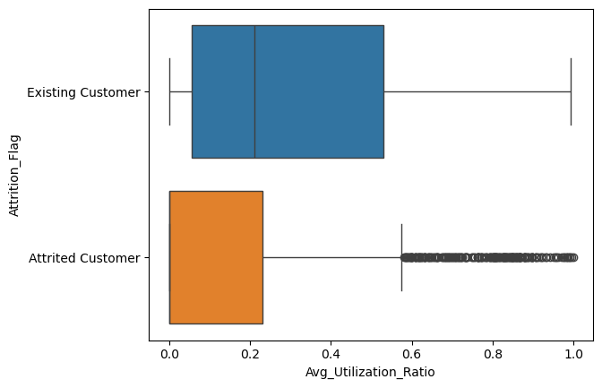

```python
sns.boxplot(data=df, x='Avg_Utilization_Ratio', hue='Attrition_Flag', y='Attrition_Flag')
```

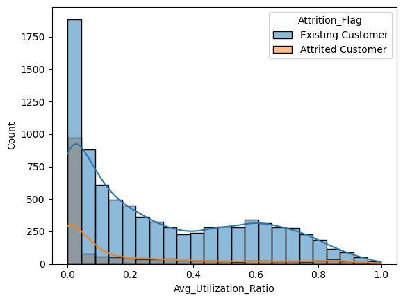

```python
sns.histplot(data=df, x='Avg_Utilization_Ratio', hue='Attrition_Flag', kde=True)
```

- ***Avg_Utilization_Ratio** has a **right skewed** distribution*
- ***Most attrited customers have very low Avg_Utilization_Ratio** close to 0 so much so that others get treated as outliers*

### Bivariate analysis

```python
#plt.figure(figsize=(50, 50))
#sns.pairplot(df, hue='Attrition_Flag', corner=True)
```

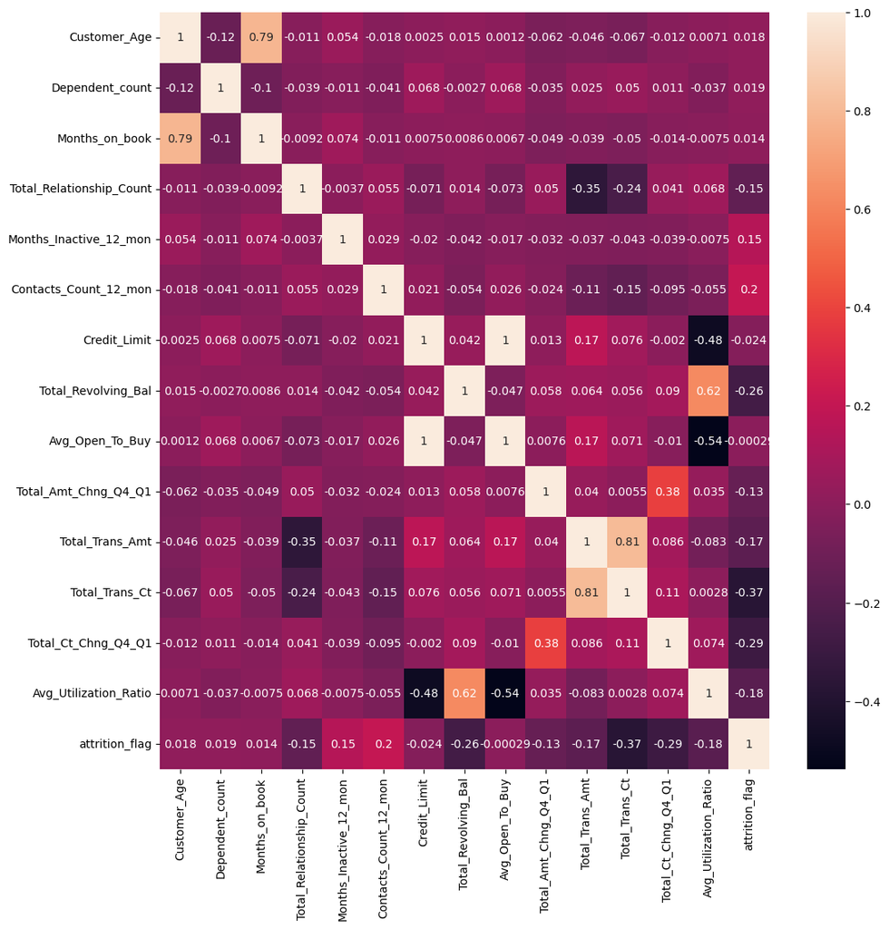

```python
plt.figure(figsize=(12, 12))
#need to find relationship of attrition flag with other attributes
codes = {'Existing Customer':0, 'Attrited Customer':1}
df_heat = df.copy()
df_heat['attrition_flag'] = df['Attrition_Flag'].map(codes).astype(int)
sns.heatmap(data=df_heat.corr(numeric_only=True), annot=True)
```

Exploring key and obvious correlation observations from visual analysis of pairplot and the heatmap:

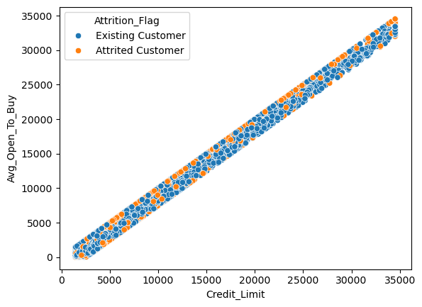

```python
sns.scatterplot(data=df, x='Credit_Limit', y='Avg_Open_To_Buy', hue='Attrition_Flag')
```

- ***Credit_Limit and Avg_Open_To_Buy** have **high correlation coefficient of 1** from the heatmap and hence are **perfectly correlated***

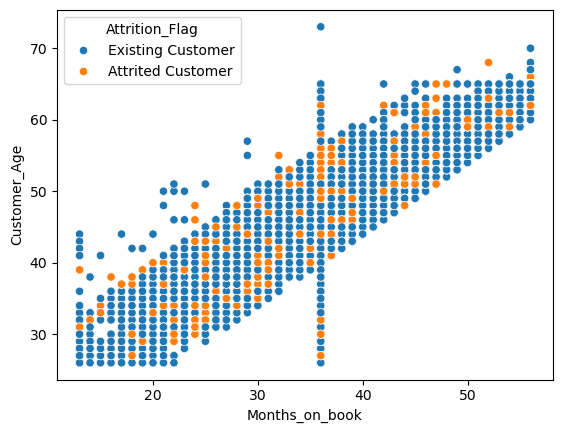

```python
sns.scatterplot(data=df, x='Months_on_book', y='Customer_Age', hue='Attrition_Flag')
```

- ***Months_on_book and Customer_Age** have **high correlation coefficient of 0.79** from the heatmap*

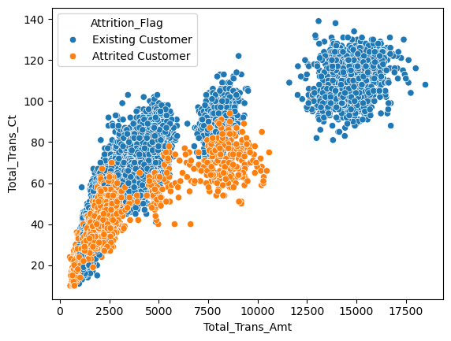

```python
sns.scatterplot(data=df, x='Total_Trans_Amt', y='Total_Trans_Ct', hue='Attrition_Flag')
```

- ***Total_Trans_Amt and Total_Trans_Ct** have **high correlation coefficient of 0.81** from the heatmap*

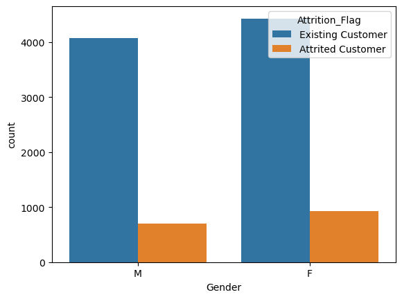

```python
sns.countplot(data=df, x='Gender', hue='Attrition_Flag')
```

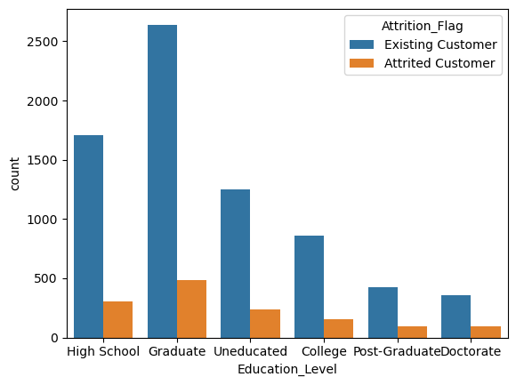

```python
sns.countplot(data=df, x='Education_Level', hue='Attrition_Flag')
```

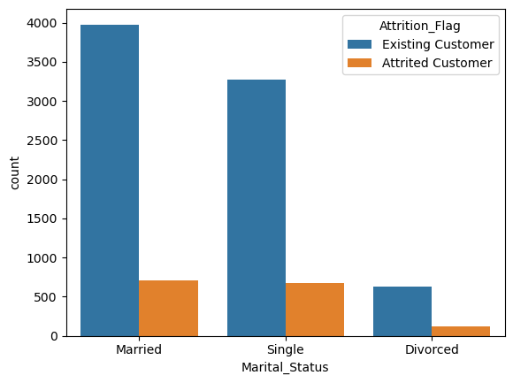

```python
sns.countplot(data=df, x='Marital_Status', hue='Attrition_Flag')
```

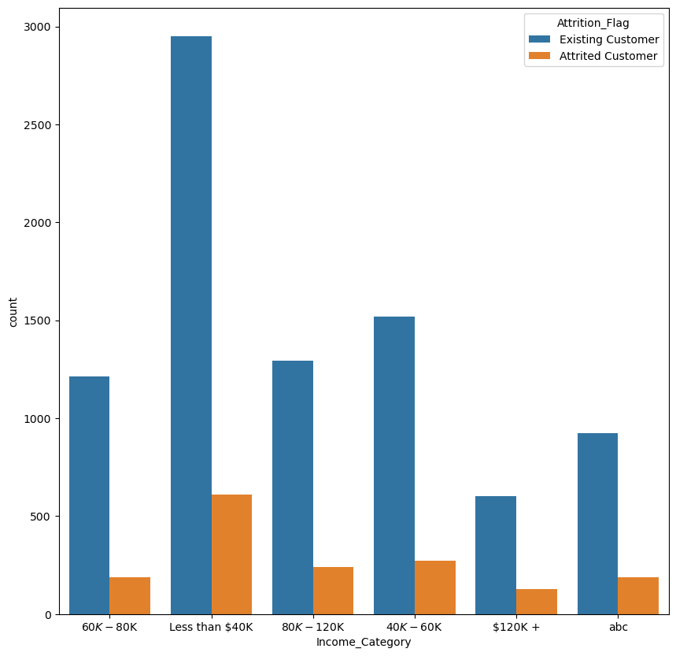

```python
plt.figure(figsize=(10, 10))
sns.countplot(data=df, x='Income_Category', hue='Attrition_Flag')
```

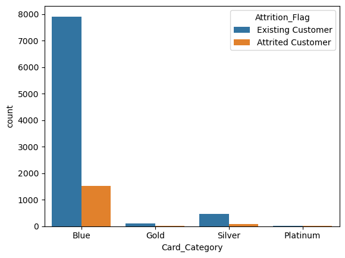

```python
sns.countplot(data=df, x='Card_Category', hue='Attrition_Flag')
```

Based on all the above countplots, we see the following:

- ***Existing customers are significantly more than attrited customers** in the data set*
- ***Gender does not influence number existing and attrited customers** much and total number of M to F customers is similar*
- *Customers with* *highest level of education of Graduate shows highest levels of attrition** as well as continued relationship with the bank*
- ***Married or Single status does not show much difference in attrition***
- *Customers with* *less that \$40K income category shows highest levels of attrition** as well as continued relationship with the bank*
- *Customers with* *Blue Card category shows highest levels of attrition** as well as continued relationship with the bank and **are highest in number compared to other card categories***
- *There are a significant number of customers who have* *Income_Category marked as 'abc' which is not a valid value***

## Data Preprocessing

```python
df.drop(columns=['Customer_Age', 'Dependent_count', 'Months_on_book', 'Credit_Limit', 'Avg_Open_To_Buy'], inplace=True)
```

```python
df.info()
```

```
<class 'pandas.core.frame.DataFrame'>
RangeIndex: 10127 entries, 0 to 10126
Data columns (total 15 columns):
 #   Column                    Non-Null Count  Dtype
---  ------                    --------------  -----
 0   Attrition_Flag            10127 non-null  object
 1   Gender                    10127 non-null  object
 2   Education_Level           8608 non-null   object
 3   Marital_Status            9378 non-null   object
 4   Income_Category           10127 non-null  object
 5   Card_Category             10127 non-null  object
 6   Total_Relationship_Count  10127 non-null  int64
 7   Months_Inactive_12_mon    10127 non-null  int64
 8   Contacts_Count_12_mon     10127 non-null  int64
 9   Total_Revolving_Bal       10127 non-null  int64
 10  Total_Amt_Chng_Q4_Q1      10127 non-null  float64
 11  Total_Trans_Amt           10127 non-null  int64
 12  Total_Trans_Ct            10127 non-null  int64
 13  Total_Ct_Chng_Q4_Q1       10127 non-null  float64
 14  Avg_Utilization_Ratio     10127 non-null  float64
dtypes: float64(3), int64(6), object(6)
memory usage: 1.2+ MB
```

We can **impute the missing values for Marital_Status and Education_Level as a different category 'Unknown'** since such rows are significant in number and we don't want to lose data.

We can also **replace the 'abc' value in Income_Category also with 'Unknown' category**

Ideally we want to impute after splitting into train, test and validation sets but **since we are imputing only categorical variables into another category, we can do it on the whole dataset with no impact on model creation**.

```python
#impute Marital_Status and Education_Level
df['Marital_Status'].fillna('Unknown', inplace=True)
df['Education_Level'].fillna('Unknown', inplace=True)

#impute Income_Category
df['Income_Category'].replace('abc', 'Unknown', inplace=True)
df.head()
```

|  | Attrition_Flag | Gender | Education_Level | Marital_Status | Income_Category | Card_Category | Total_Relationship_Count | Months_Inactive_12_mon | Contacts_Count_12_mon | Total_Revolving_Bal | Total_Amt_Chng_Q4_Q1 | Total_Trans_Amt | Total_Trans_Ct | Total_Ct_Chng_Q4_Q1 | Avg_Utilization_Ratio |
| --- | --- | --- | --- | --- | --- | --- | --- | --- | --- | --- | --- | --- | --- | --- | --- |
| 0 | Existing Customer | M | High School | Married | $60K - $80K | Blue | 5 | 1 | 3 | 777 | 1.335 | 1144 | 42 | 1.625 | 0.061 |
| 1 | Existing Customer | F | Graduate | Single | Less than $40K | Blue | 6 | 1 | 2 | 864 | 1.541 | 1291 | 33 | 3.714 | 0.105 |
| 2 | Existing Customer | M | Graduate | Married | $80K - $120K | Blue | 4 | 1 | 0 | 0 | 2.594 | 1887 | 20 | 2.333 | 0.000 |
| 3 | Existing Customer | F | High School | Unknown | Less than $40K | Blue | 3 | 4 | 1 | 2517 | 1.405 | 1171 | 20 | 2.333 | 0.760 |
| 4 | Existing Customer | M | Uneducated | Married | $60K - $80K | Blue | 5 | 1 | 0 | 0 | 2.175 | 816 | 28 | 2.500 | 0.000 |

```python
df['Income_Category'].value_counts()
```

```
Income_Category
Less than $40K    3561
$40K - $60K       1790
$80K - $120K      1535
$60K - $80K       1402
Unknown           1112
$120K +            727
Name: count, dtype: int64
```

```python
df['Marital_Status'].value_counts()
```

```
Marital_Status
Married     4687
Single      3943
Unknown      749
Divorced     748
Name: count, dtype: int64
```

```python
df['Education_Level'].value_counts()
```

```
Education_Level
Graduate         3128
High School      2013
Unknown          1519
Uneducated       1487
College          1013
Post-Graduate     516
Doctorate         451
Name: count, dtype: int64
```

Converting all object data type values into categorical variables:

```python
# convert to categorical
for col in df.columns:
    if df[col].dtype == 'object':
        df[col] = pd.Categorical(df[col])
```

```python
df.info()
```

```
<class 'pandas.core.frame.DataFrame'>
RangeIndex: 10127 entries, 0 to 10126
Data columns (total 15 columns):
 #   Column                    Non-Null Count  Dtype
---  ------                    --------------  -----
 0   Attrition_Flag            10127 non-null  category
 1   Gender                    10127 non-null  category
 2   Education_Level           10127 non-null  category
 3   Marital_Status            10127 non-null  category
 4   Income_Category           10127 non-null  category
 5   Card_Category             10127 non-null  category
 6   Total_Relationship_Count  10127 non-null  int64
 7   Months_Inactive_12_mon    10127 non-null  int64
 8   Contacts_Count_12_mon     10127 non-null  int64
 9   Total_Revolving_Bal       10127 non-null  int64
 10  Total_Amt_Chng_Q4_Q1      10127 non-null  float64
 11  Total_Trans_Amt           10127 non-null  int64
 12  Total_Trans_Ct            10127 non-null  int64
 13  Total_Ct_Chng_Q4_Q1       10127 non-null  float64
 14  Avg_Utilization_Ratio     10127 non-null  float64
dtypes: category(6), float64(3), int64(6)
memory usage: 772.7 KB
```

We can do encoding for all the categorical columns as follows:

```python
#Encoding for categorical variables
#Boolean label encoding - Attrition_Flag, Gender
#One hot encoding - Education_Level, Marital_Status, c, Card_Category

replaceStruct = {
    "Attrition_Flag" : {"Existing Customer": 0, "Attrited Customer": 1},
    "Gender" : {"M": 0, "F": 1}
}

oneHotCols = ["Education_Level", "Marital_Status", "Income_Category", "Card_Category"]

df = df.replace(replaceStruct)
df = pd.get_dummies(df, columns=oneHotCols)

#Drop one column from the one hot encoded features to reduce collinearity
df.drop(columns=['Education_Level_Unknown', 'Marital_Status_Unknown', 'Income_Category_Unknown', 'Card_Category_Platinum'], inplace=True)

#Converting Gender into int64 for SMOTE oversampling later as it does not handle categorical values well
df['Gender'] = df['Gender'].astype('int64')
df.info()
```

```
<class 'pandas.core.frame.DataFrame'>
RangeIndex: 10127 entries, 0 to 10126
Data columns (total 28 columns):
 #   Column                          Non-Null Count  Dtype
---  ------                          --------------  -----
 0   Attrition_Flag                  10127 non-null  category
 1   Gender                          10127 non-null  int64
 2   Total_Relationship_Count        10127 non-null  int64
 3   Months_Inactive_12_mon          10127 non-null  int64
 4   Contacts_Count_12_mon           10127 non-null  int64
 5   Total_Revolving_Bal             10127 non-null  int64
 6   Total_Amt_Chng_Q4_Q1            10127 non-null  float64
 7   Total_Trans_Amt                 10127 non-null  int64
 8   Total_Trans_Ct                  10127 non-null  int64
 9   Total_Ct_Chng_Q4_Q1             10127 non-null  float64
```

[output cut: 20 more lines]

**To avoid any data leakage**, we will now split the dataset into training, validation and test set before scaling

```python
X = df.iloc[:, 1:]
y = df.iloc[:, 0] #Attrition_Flag is target column
seed = 5

#separate first into temp and test data 80:20
X_train, X_test, y_train, y_test = train_test_split(X, y, stratify=y, test_size=0.2, random_state=seed)
X_test.shape #shape of test set
```

```
(2026, 27)
```

```python
X_train.shape #shape of training set
```

```
(8101, 27)
```

```python
#Applying RobustScaler to scale with outliers to only the numerical features
scaler = RobustScaler()

#to avoid data leakage we will fit the scaler on training set and then transform training and test sets
scaled_X_train = scaler.fit_transform(X_train)
scaled_X_test = scaler.transform(X_test)
#scaled_x_test can now be used during final peformance assessment of models
```

## Model Building - Original Data

Let us consider what is the effect of false positives and false negatives on the problem statement that can help determine the evaluation metrics to optimise.

False positive - **Predicting that a customer will attrite when they actually won't will lead to a loss of processing resources** False negative - **Predicting that a customer will not attrite when they actually will, will lead to loss of business**

**False negatives will have a more negative impact for the bank** and hence the model needs to drive towards reducing false negatives. Hence, **recall of the model is the best evaluation metric**.

Preparing some common functions that can be used to evaluate models henceforth:

```python
#Building common functions to display model performance
def confusion_matrix_map(model, target, predicted):
    cm = confusion_matrix(target, predicted)
    labels = np.asarray(
        [
            ["{0:0.0f}".format(item) + "\n{0:.2%}".format(item / cm.flatten().sum())]
            for item in cm.flatten()
        ]
    ).reshape(cm.shape[0], cm.shape[1])

    plt.figure(figsize=(6, 4))
    sns.heatmap(cm, annot=labels, cmap="flare", fmt="")
    plt.ylabel("Truth")
    plt.xlabel("Prediction")

def model_performance(model, target, predicted):
    print('Confusion Matrix:')
    print(confusion_matrix_map(model, target, predicted))
    print('Classification Report:')
    print(classification_report(target, predicted))

def get_metrics(model, X_a, X_b, y_a, y_b):
    # use model to predict on both X_a and X_b
    score_list = []
    y_pred_a = model.predict(X_a)
    y_pred_b = model.predict(X_b)
    train_f1_score = f1_score(y_a, y_pred_a)
    test_f1_score = f1_score(y_b, y_pred_b)
    train_acc_score = accuracy_score(y_a, y_pred_a)
    test_acc_score = accuracy_score(y_b, y_pred_b)
    train_recall_score = recall_score(y_a, y_pred_a)
    test_recall_score = recall_score(y_b, y_pred_b)
    train_precision_score = precision_score(y_a, y_pred_a)
    test_precision_score = precision_score(y_b, y_pred_b)

    print("Accuracy on training data: ", train_acc_score)
    print("Accuracy on test data: ", test_acc_score)
    print("Recall score on training data: ", train_recall_score)
    print("Recall score on test data: ", test_recall_score)
    print("Precision score on training data: ", train_precision_score)
    print("Precision score on test data: ", test_precision_score)
    print("F1 score on training data: ", train_f1_score)
    print("F1 score on test data: ", test_f1_score)
    score_list.extend((train_acc_score, test_acc_score, train_recall_score, test_recall_score,
                       train_precision_score, test_precision_score, train_f1_score, test_f1_score))
    #return the score list for final comparison
    return score_list

def evaluate_models(models, xtrain, ytrain, seed):
    # comparison dataframe
    comp_metrics_df = pd.DataFrame(columns=['Model', 'Train Folds Acc', 'Test Fold Acc', 'Train Folds Recall',
                                            'Test Fold Recall', 'Train Folds Precision', 'Test Fold Precision', 'Train Folds f1', 'Test Fold f1'])
    #evaluation metrics for comparing model scores
    scoring_params = ('recall', 'precision', 'accuracy', 'f1')

    #setup the 10-fold strategy on training data
    kfold = StratifiedKFold(n_splits=10, shuffle=True, random_state=seed)

    #loop through the models
    for idx, model_tuple in enumerate(models):
        # to avoid data leakage set scaler inside the pipeline so that for every iteration of train and test fold, the folds are scaled
        pipe = Pipeline(steps=[('scaler', RobustScaler()), model_tuple])
        # pipe represents the model, so calculate cross validation recall, precision, accuracy, f1 scores
        scores = cross_validate(estimator=pipe, X=xtrain, y=ytrain, cv=kfold, scoring=scoring_params, return_train_score=True)
        # take all scores per model to populate in a dataframe for comparison
        # Train fold scores is the average of all scores that have run for each iteration on k-1 = 9 folds
        # Test fold scores is the average of all scores that have run for each iteration on test fold
        comp_metrics_df.loc[len(comp_metrics_df.index)] = [model_tuple[0], np.mean(scores['train_accuracy']), np.mean(scores['test_accuracy']),
                                                           np.mean(scores['train_recall']), np.mean(scores['test_recall']),
                                                           np.mean(scores['train_precision']),
                                                           np.mean(scores['test_precision']), np.mean(scores['train_f1']),
                                                           np.mean(scores['test_f1'])]
    return comp_metrics_df
```

We will apply following supervised learning classification models learnt in the course to the data set and compare the performance:

- ***Decision trees***
- ***Random Forest***
- ***Bagging***
- ***AdaBoost***
- ***GradientBoost***

Since the data has a majority class for existing customers compared to attrited customers, we can use the **Stratified K-Fold strategy** for the models.

```python
models = []

#to loop through each model
models.append(('Decision Tree', DecisionTreeClassifier(random_state=seed)))
models.append(('Random Forest', RandomForestClassifier(random_state=seed)))
models.append(('Bagging', BaggingClassifier(random_state=seed)))
models.append(('AdaBoost', AdaBoostClassifier(random_state=seed)))
models.append(('GradientBoost', GradientBoostingClassifier(random_state=seed)))

orig_scores_df = evaluate_models(models, X_train, y_train, seed)
orig_scores_df
```

|  | Model | Train Folds Acc | Test Fold Acc | Train Folds Recall | Test Fold Recall | Train Folds Precision | Test Fold Precision | Train Folds f1 | Test Fold f1 |
| --- | --- | --- | --- | --- | --- | --- | --- | --- | --- |
| 0 | Decision Tree | 1.000000 | 0.934947 | 1.000000 | 0.792601 | 1.000000 | 0.800611 | 1.000000 | 0.796493 |
| 1 | Random Forest | 0.999986 | 0.956055 | 0.999915 | 0.792619 | 1.000000 | 0.922931 | 0.999957 | 0.852730 |
| 2 | Bagging | 0.995995 | 0.951857 | 0.979605 | 0.804093 | 0.995406 | 0.886055 | 0.987439 | 0.842634 |
| 3 | AdaBoost | 0.960074 | 0.954820 | 0.849205 | 0.832566 | 0.896932 | 0.880334 | 0.872392 | 0.855504 |
| 4 | GradientBoost | 0.972898 | 0.962720 | 0.882062 | 0.840998 | 0.945661 | 0.920882 | 0.912750 | 0.878749 |

## Model Building - Oversampled data

```python
before_total_att = sum(y_train == 1)
before_total_ext = sum(y_train == 0)
```

```python
before_total_att #number of attrited samples before oversampling
```

```
1302
```

```python
before_total_ext #number of existing samples before oversampling
```

```
6799
```

Our original dataset is imbalanced and hence we will use **SMOTE to oversample the minority class**.

```python
smote = SMOTE(sampling_strategy='minority', random_state=seed, k_neighbors=5)
up_X_train, up_y_train = smote.fit_resample(X_train, y_train)
```

```python
after_total_att = sum(up_y_train == 1)
after_total_ext = sum(up_y_train == 0)
```

```python
after_total_att #number of attrited samples after oversampling
```

```
6799
```

```python
after_total_ext #number of existing samples after oversampling
```

```
6799
```

```python
up_models = []

#to loop through each model
up_models.append(('UpSampled Decision Tree', DecisionTreeClassifier(random_state=seed)))
up_models.append(('UpSampled Random Forest', RandomForestClassifier(random_state=seed)))
up_models.append(('UpSampled Bagging', BaggingClassifier(random_state=seed)))
up_models.append(('UpSampled AdaBoost', AdaBoostClassifier(random_state=seed)))
up_models.append(('UpSampled GradientBoost', GradientBoostingClassifier(random_state=seed)))

up_scores_df = evaluate_models(up_models, up_X_train, up_y_train, seed)
up_scores_df
```

|  | Model | Train Folds Acc | Test Fold Acc | Train Folds Recall | Test Fold Recall | Train Folds Precision | Test Fold Precision | Train Folds f1 | Test Fold f1 |
| --- | --- | --- | --- | --- | --- | --- | --- | --- | --- |
| 0 | UpSampled Decision Tree | 1.000000 | 0.958744 | 1.000000 | 0.964553 | 1.000000 | 0.953505 | 1.000000 | 0.958977 |
| 1 | UpSampled Random Forest | 1.000000 | 0.978674 | 1.000000 | 0.985587 | 1.000000 | 0.972154 | 1.000000 | 0.978823 |
| 2 | UpSampled Bagging | 0.998529 | 0.970658 | 0.998382 | 0.974408 | 0.998676 | 0.967182 | 0.998529 | 0.970769 |
| 3 | UpSampled AdaBoost | 0.962780 | 0.961172 | 0.968525 | 0.966908 | 0.957526 | 0.955951 | 0.962993 | 0.961391 |
| 4 | UpSampled GradientBoost | 0.976631 | 0.970363 | 0.980765 | 0.974409 | 0.972723 | 0.966617 | 0.976727 | 0.970481 |

## Model Building - Undersampled data

Our original dataset is imbalanced and hence we will use **RandomUnderSampler to downsample the majority class**.

```python
smote = RandomUnderSampler(sampling_strategy='majority', random_state=seed)
down_X_train, down_y_train = smote.fit_resample(X_train, y_train)
```

```python
after_total_att = sum(down_y_train == 1)
after_total_ext = sum(down_y_train == 0)
```

```python
after_total_att #number of attrited samples after oversampling
```

```
1302
```

```python
after_total_ext #number of existing samples after oversampling
```

```
1302
```

```python
down_models = []

#to loop through each model
down_models.append(('DownSampled Decision Tree', DecisionTreeClassifier(random_state=seed)))
down_models.append(('DownSampled Random Forest', RandomForestClassifier(random_state=seed)))
down_models.append(('DownSampled Bagging', BaggingClassifier(random_state=seed)))
down_models.append(('DownSampled AdaBoost', AdaBoostClassifier(random_state=seed)))
down_models.append(('DownSampled GradientBoost', GradientBoostingClassifier(random_state=seed)))

down_scores_df = evaluate_models(down_models, down_X_train, down_y_train, seed)
down_scores_df
```

|  | Model | Train Folds Acc | Test Fold Acc | Train Folds Recall | Test Fold Recall | Train Folds Precision | Test Fold Precision | Train Folds f1 | Test Fold f1 |
| --- | --- | --- | --- | --- | --- | --- | --- | --- | --- |
| 0 | DownSampled Decision Tree | 1.000000 | 0.888277 | 1.000000 | 0.884821 | 1.000000 | 0.891307 | 1.000000 | 0.887813 |
| 1 | DownSampled Random Forest | 1.000000 | 0.930894 | 1.000000 | 0.938573 | 1.000000 | 0.924751 | 1.000000 | 0.931379 |
| 2 | DownSampled Bagging | 0.995989 | 0.925122 | 0.994538 | 0.921668 | 0.997434 | 0.928580 | 0.995983 | 0.924757 |
| 3 | DownSampled AdaBoost | 0.949906 | 0.932800 | 0.956563 | 0.940100 | 0.944009 | 0.926930 | 0.950240 | 0.933236 |
| 4 | DownSampled GradientBoost | 0.974057 | 0.943940 | 0.983274 | 0.950065 | 0.965482 | 0.938856 | 0.974294 | 0.944175 |

## Model Performance Improvement using Hyperparameter Tuning

Let us combine all of the above scores for 5 models for original, upsampled and downsampled data into a common dataframe to compare and analyse:

```python
final_comp_df = pd.concat([orig_scores_df, up_scores_df, down_scores_df], axis=0)
final_comp_df = final_comp_df.sort_values('Test Fold Recall', ascending=False)
final_comp_df.reset_index(drop=True)
#since recall metric is most important evaluation metric for the problem, sorting the comparison df based on Test Fold Recall
```

|  | Model | Train Folds Acc | Test Fold Acc | Train Folds Recall | Test Fold Recall | Train Folds Precision | Test Fold Precision | Train Folds f1 | Test Fold f1 |
| --- | --- | --- | --- | --- | --- | --- | --- | --- | --- |
| 0 | UpSampled Random Forest | 1.000000 | 0.978674 | 1.000000 | 0.985587 | 1.000000 | 0.972154 | 1.000000 | 0.978823 |
| 1 | UpSampled GradientBoost | 0.976631 | 0.970363 | 0.980765 | 0.974409 | 0.972723 | 0.966617 | 0.976727 | 0.970481 |
| 2 | UpSampled Bagging | 0.998529 | 0.970658 | 0.998382 | 0.974408 | 0.998676 | 0.967182 | 0.998529 | 0.970769 |
| 3 | UpSampled AdaBoost | 0.962780 | 0.961172 | 0.968525 | 0.966908 | 0.957526 | 0.955951 | 0.962993 | 0.961391 |
| 4 | UpSampled Decision Tree | 1.000000 | 0.958744 | 1.000000 | 0.964553 | 1.000000 | 0.953505 | 1.000000 | 0.958977 |
| 5 | DownSampled GradientBoost | 0.974057 | 0.943940 | 0.983274 | 0.950065 | 0.965482 | 0.938856 | 0.974294 | 0.944175 |
| 6 | DownSampled AdaBoost | 0.949906 | 0.932800 | 0.956563 | 0.940100 | 0.944009 | 0.926930 | 0.950240 | 0.933236 |
| 7 | DownSampled Random Forest | 1.000000 | 0.930894 | 1.000000 | 0.938573 | 1.000000 | 0.924751 | 1.000000 | 0.931379 |
| 8 | DownSampled Bagging | 0.995989 | 0.925122 | 0.994538 | 0.921668 | 0.997434 | 0.928580 | 0.995983 | 0.924757 |
| 9 | DownSampled Decision Tree | 1.000000 | 0.888277 | 1.000000 | 0.884821 | 1.000000 | 0.891307 | 1.000000 | 0.887813 |
| 10 | GradientBoost | 0.972898 | 0.962720 | 0.882062 | 0.840998 | 0.945661 | 0.920882 | 0.912750 | 0.878749 |
| 11 | AdaBoost | 0.960074 | 0.954820 | 0.849205 | 0.832566 | 0.896932 | 0.880334 | 0.872392 | 0.855504 |
| 12 | Bagging | 0.995995 | 0.951857 | 0.979605 | 0.804093 | 0.995406 | 0.886055 | 0.987439 | 0.842634 |
| 13 | Random Forest | 0.999986 | 0.956055 | 0.999915 | 0.792619 | 1.000000 | 0.922931 | 0.999957 | 0.852730 |
| 14 | Decision Tree | 1.000000 | 0.934947 | 1.000000 | 0.792601 | 1.000000 | 0.800611 | 1.000000 | 0.796493 |

- *Rows with index* *0, 4, 7, 9, 14** have all the training scores as 1.0 indicating **very high overfitting to the training data and test data with high values***
- *Rows* *2, 8, 12, 13** have training scores very close to 1 indicating **high overfitting to the training data and test data with high values***
- *Therefore rows* *1, 3, 5, 6, 10, 11** are **good candidates for further hyperparameter tuning***

```python
candidates_df = final_comp_df.iloc[[1, 3, 5, 6, 10, 11]]
#arrange by decresing recall score to pick top 3 models
candidates_df.reset_index(drop=True).sort_values('Test Fold Recall', ascending=False)
```

|  | Model | Train Folds Acc | Test Fold Acc | Train Folds Recall | Test Fold Recall | Train Folds Precision | Test Fold Precision | Train Folds f1 | Test Fold f1 |
| --- | --- | --- | --- | --- | --- | --- | --- | --- | --- |
| 0 | UpSampled GradientBoost | 0.976631 | 0.970363 | 0.980765 | 0.974409 | 0.972723 | 0.966617 | 0.976727 | 0.970481 |
| 1 | UpSampled AdaBoost | 0.962780 | 0.961172 | 0.968525 | 0.966908 | 0.957526 | 0.955951 | 0.962993 | 0.961391 |
| 2 | DownSampled GradientBoost | 0.974057 | 0.943940 | 0.983274 | 0.950065 | 0.965482 | 0.938856 | 0.974294 | 0.944175 |
| 3 | DownSampled AdaBoost | 0.949906 | 0.932800 | 0.956563 | 0.940100 | 0.944009 | 0.926930 | 0.950240 | 0.933236 |
| 4 | GradientBoost | 0.972898 | 0.962720 | 0.882062 | 0.840998 | 0.945661 | 0.920882 | 0.912750 | 0.878749 |
| 5 | AdaBoost | 0.960074 | 0.954820 | 0.849205 | 0.832566 | 0.896932 | 0.880334 | 0.872392 | 0.855504 |

The top 3 models with highest recall score are:

- ***GradientBoost on Upsampled data***
- ***AdaBoost on Upsampled data***
- ***GradientBoost on Downsampled data***

Let us check the performance of the base models on the test data:

```python
#scale the up_X_train, down_X_train using RobustScaler to be used for the selected base models
#need 2 separate scalers as the variance of upsampled and downsampled data is different
scaler_up = RobustScaler()
scaler_down = RobustScaler()

#fit and transform both the scaler for upsampled and downsampled data
scaled_up_X_train = scaler_up.fit_transform(up_X_train)
scaled_down_X_train = scaler_down.fit_transform(down_X_train)

#transform test set using the 2 scalers
scaled_up_X_test = scaler_up.transform(X_test)
scaled_down_X_test = scaler_down.transform(X_test)
```

```
Confusion Matrix:
None
Classification Report:
              precision    recall  f1-score   support

           0       0.98      0.97      0.98      6799
           1       0.97      0.98      0.98      6799

    accuracy                           0.98     13598
   macro avg       0.98      0.98      0.98     13598
weighted avg       0.98      0.98      0.98     13598
```

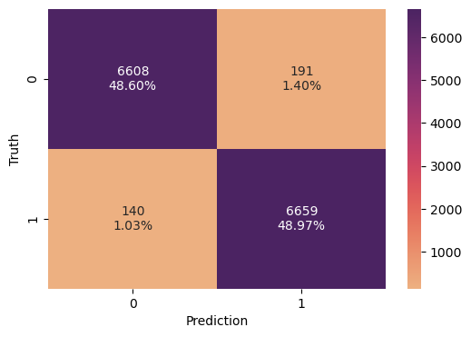

```python
# GradientBoost on Upsampled data
gboost_up = GradientBoostingClassifier(random_state=seed)
gboost_up.fit(scaled_up_X_train, up_y_train)

#performance on training data
y_pred_train = gboost_up.predict(scaled_up_X_train)
model_performance(gboost_up, up_y_train, y_pred_train)
```

```
Confusion Matrix:
None
Classification Report:
              precision    recall  f1-score   support

           0       0.98      0.96      0.97      1701
           1       0.81      0.89      0.85       325

    accuracy                           0.95      2026
   macro avg       0.90      0.92      0.91      2026
weighted avg       0.95      0.95      0.95      2026
```

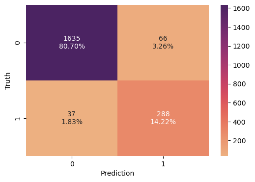

```python
#performance on test data
y_pred_test = gboost_up.predict(scaled_up_X_test)
model_performance(gboost_up, y_test, y_pred_test)
```

- *The performance of* *GradientBoost on Upsampled data** shows a **training data accuracy of 98% compared to 95% for the test data***
- *Since our* *evaluation metric** is Recall and the **class of interest 'Attrited Customer'** and we are looking to **minimise false negatives**, we are **interested in Recall(class=1)**, this value is **89% on the test data whereas it is 98% on training data***

```
Confusion Matrix:
None
Classification Report:
              precision    recall  f1-score   support

           0       0.97      0.96      0.96      6799
           1       0.96      0.97      0.96      6799

    accuracy                           0.96     13598
   macro avg       0.96      0.96      0.96     13598
weighted avg       0.96      0.96      0.96     13598
```

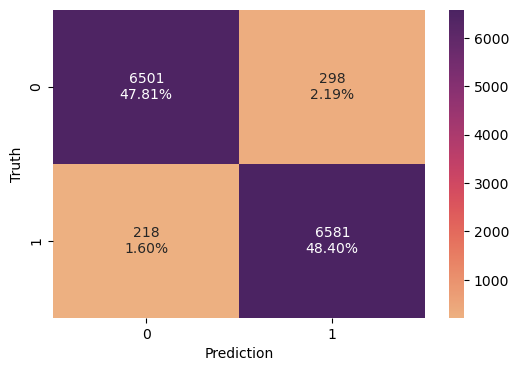

```python
# AdaBoost on Upsampled data
adaboost_up = AdaBoostClassifier(random_state=seed)
adaboost_up.fit(scaled_up_X_train, up_y_train)

#performance on training data
y_pred_train = adaboost_up.predict(scaled_up_X_train)
model_performance(adaboost_up, up_y_train, y_pred_train)
```

```
Confusion Matrix:
None
Classification Report:
              precision    recall  f1-score   support

           0       0.97      0.94      0.96      1701
           1       0.75      0.86      0.80       325

    accuracy                           0.93      2026
   macro avg       0.86      0.90      0.88      2026
weighted avg       0.94      0.93      0.93      2026
```

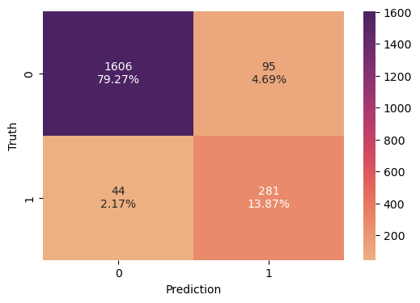

```python
#performance on test data
y_pred_test = adaboost_up.predict(scaled_up_X_test)
model_performance(adaboost_up, y_test, y_pred_test)
```

```
Confusion Matrix:
None
Classification Report:
              precision    recall  f1-score   support

           0       0.98      0.96      0.97      1302
           1       0.97      0.98      0.97      1302

    accuracy                           0.97      2604
   macro avg       0.97      0.97      0.97      2604
weighted avg       0.97      0.97      0.97      2604
```

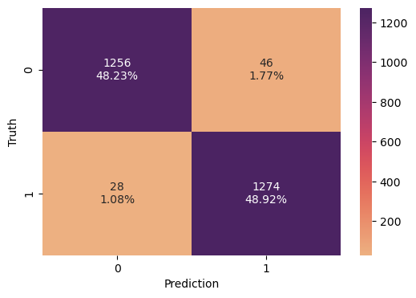

```python
# GradientBoost on Downsampled data
gboost_down = GradientBoostingClassifier(random_state=seed)
gboost_down.fit(scaled_down_X_train, down_y_train)

#performance on training data
y_pred_train = gboost_down.predict(scaled_down_X_train)
model_performance(gboost_down, down_y_train, y_pred_train)
```

```
Confusion Matrix:
None
Classification Report:
              precision    recall  f1-score   support

           0       0.99      0.93      0.96      1701
           1       0.72      0.94      0.82       325

    accuracy                           0.93      2026
   macro avg       0.86      0.94      0.89      2026
weighted avg       0.95      0.93      0.94      2026
```

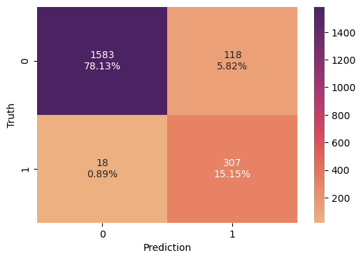

```python
#performance on test data
y_pred_test = gboost_down.predict(scaled_down_X_test)
model_performance(gboost_down, y_test, y_pred_test)
```

- *The performance of* *GradientBoost on Downsampled data** shows a **training data accuracy of 97% compared to 93% for the test data***
- Since our **evaluation metric is Recall** and the **class of interest 'Attrited Customer'** and we are looking to **minimise false negatives**, we are **interested in Recall(class=1)**, this value is **94% on the test data whereas it is 98% on training data**
- *This model enjoys the* *best Recall score** from among the base model comparison*

### Tuning GradientBoost on Upsampled data

```python
# defining model pipeline; scaler included
pipe = Pipeline(steps=[('scaler', RobustScaler()), ('Tuned UpSampled GradientBoost', GradientBoostingClassifier(random_state=seed))])

# Parameter grid to pass in RandomizedSearchCV
param_grid={'Tuned UpSampled GradientBoost__n_estimators':np.arange(100, 1000, 100),
            'Tuned UpSampled GradientBoost__learning_rate':np.arange(0.05, 1, 0.05)}

# Type of scoring used to compare parameter combinations
scorer = make_scorer(recall_score)

#Calling RandomizedSearchCV
gradient_up_tuned = RandomizedSearchCV(estimator=pipe, param_distributions=param_grid, n_iter=20, scoring=scorer, cv=10,
                                       random_state=seed, n_jobs = -1)

#Fitting parameters in RandomizedSearchCV
gradient_up_tuned.fit(up_X_train,up_y_train)

print("Best parameters are {} with CV score={}:" .format(gradient_up_tuned.best_params_,gradient_up_tuned.best_score_))
```

```
Best parameters are {'Tuned UpSampled GradientBoost__n_estimators': 900, 'Tuned UpSampled GradientBoost__learning_rate': 0.3} with CV score=0.9789699384908603:
```

- *We have* *improved the recall performance** of the GradientBoost on UpSampled data from **97.44% to 97.89%** on the training folds*

```python
# GradientBoost on Upsampled data using the best parameters identified above
gboost_up = GradientBoostingClassifier(random_state=seed, n_estimators=900, learning_rate=0.3)
gboost_up.fit(scaled_up_X_train, up_y_train)
```

```
GradientBoostingClassifier(learning_rate=0.3, n_estimators=900, random_state=5)
```

```
Confusion Matrix:
None
Classification Report:
              precision    recall  f1-score   support

           0       0.98      0.98      0.98      1701
           1       0.87      0.89      0.88       325

    accuracy                           0.96      2026
   macro avg       0.93      0.93      0.93      2026
weighted avg       0.96      0.96      0.96      2026
```

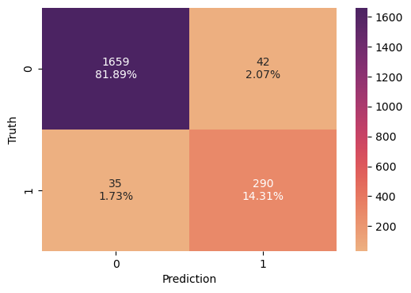

```python
#performance on test data
y_pred_test = gboost_up.predict(scaled_up_X_test)
model_performance(gboost_up, y_test, y_pred_test)
```

- *The* *Tuned GradientBoost model on upsampled data** has been tuned to give a **higher accuracy of 96% compared to base GradientBoost on upsampled data***
- *The* *Tuned GradientBoost model on upsampled data** gives the **same recall(class=1) of 89%** as base model*

### Tuning AdaBoost on Upsampled data

```python
# defining model; scaler included
pipe = Pipeline(steps=[('scaler', RobustScaler()), ('Tuned UpSampled AdaBoost', AdaBoostClassifier(random_state=seed))])

# Parameter grid to pass in RandomizedSearchCV
param_grid={'Tuned UpSampled AdaBoost__n_estimators':np.arange(100, 1000, 100),
            'Tuned UpSampled AdaBoost__learning_rate':np.arange(0.05, 1, 0.05)}

# Type of scoring used to compare parameter combinations
scorer = make_scorer(recall_score)

#Calling RandomizedSearchCV
ada_up_tuned = RandomizedSearchCV(estimator=pipe, param_distributions=param_grid, n_iter=20, scoring=scorer, cv=10, random_state=seed, n_jobs = -1)

#Fitting parameters in RandomizedSearchCV
ada_up_tuned.fit(up_X_train,up_y_train)

print("Best parameters are {} with CV score={}:" .format(ada_up_tuned.best_params_,ada_up_tuned.best_score_))
```

```
Best parameters are {'Tuned UpSampled AdaBoost__n_estimators': 900, 'Tuned UpSampled AdaBoost__learning_rate': 0.1} with CV score=0.9691156978255219:
```

- *We have* *improved the recall performance** of the AdaBoost on UpSampled data from **96.69% to 96.91%** on the training folds*

```python
# AdaBoost on Upsampled data using the best parameters identified above
adaboost_up = AdaBoostClassifier(random_state=seed, n_estimators=900, learning_rate=0.1)
adaboost_up.fit(scaled_up_X_train, up_y_train)
```

```
AdaBoostClassifier(learning_rate=0.1, n_estimators=900, random_state=5)
```

```
Confusion Matrix:
None
Classification Report:
              precision    recall  f1-score   support

           0       0.98      0.95      0.97      1701
           1       0.78      0.89      0.83       325

    accuracy                           0.94      2026
   macro avg       0.88      0.92      0.90      2026
weighted avg       0.95      0.94      0.94      2026
```

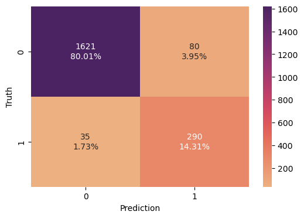

```python
#performance on test data
y_pred_test = adaboost_up.predict(scaled_up_X_test)
model_performance(adaboost_up, y_test, y_pred_test)
```

### Tuning GradientBoost on Downsampled data

```python
# defining model; scaler included
pipe = Pipeline(steps=[('scaler', RobustScaler()), ('Tuned DownSampled GradientBoost', GradientBoostingClassifier(random_state=seed))])

# Parameter grid to pass in RandomizedSearchCV
param_grid={'Tuned DownSampled GradientBoost__n_estimators':np.arange(100, 1000, 100),
            'Tuned DownSampled GradientBoost__learning_rate':np.arange(0.05, 1, 0.05)}

# Type of scoring used to compare parameter combinations
scorer = make_scorer(recall_score)

#Calling RandomizedSearchCV
gradient_down_tuned = RandomizedSearchCV(estimator=pipe, param_distributions=param_grid, n_iter=20, scoring=scorer, cv=10, random_state=seed, n_jobs = -1)

#Fitting parameters in RandomizedSearchCV
gradient_down_tuned.fit(down_X_train,down_y_train)

print("Best parameters are {} with CV score={}:" .format(gradient_down_tuned.best_params_,gradient_down_tuned.best_score_))
```

```
Best parameters are {'Tuned DownSampled GradientBoost__n_estimators': 800, 'Tuned DownSampled GradientBoost__learning_rate': 0.8500000000000001} with CV score=0.9577627715795654:
```

- *We have* *improved the recall performance** of the GradientBoost on DownSampled data from **95% to 95.77%** on the training folds*

```python
# GradientBoost on Downsampled data
gboost_down = GradientBoostingClassifier(random_state=seed, n_estimators=800, learning_rate=0.85)
gboost_down.fit(scaled_down_X_train, down_y_train)
```

```
GradientBoostingClassifier(learning_rate=0.85, n_estimators=800, random_state=5)
```

```
Confusion Matrix:
None
Classification Report:
              precision    recall  f1-score   support

           0       0.99      0.94      0.96      1701
           1       0.75      0.94      0.84       325

    accuracy                           0.94      2026
   macro avg       0.87      0.94      0.90      2026
weighted avg       0.95      0.94      0.94      2026
```

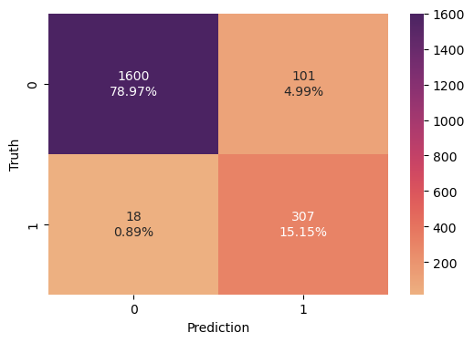

```python
#performance on test data
y_pred_test = gboost_down.predict(scaled_down_X_test)
model_performance(gboost_down, y_test, y_pred_test)
```

- *The* *Tuned GradientBoost model on downsampled data** has been tuned to give a **higher accuracy of 94% compared to base GradientBoost on downsampled data***
- *The* *Tuned GradientBoost model on downsampled data** same **recall(class=1) of 94%** as the base model*

## Model Performance Comparison and Final Model Selection

From the above analysis, we find that **Tuned GradientBoost model on the downsampled data seems to be the best fit model** with a **recall score of 94% for both 'attrited' and existing customers**. It also enjoys an **accuracy score of 94%**. The model **generalises well over test data and hence does not overfit**.

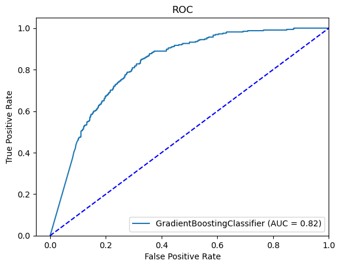

```python
#plotting ROC curve of the Tuned GradientBoost on downsampled data
RocCurveDisplay.from_estimator(gboost_down, scaled_X_test, y_test)
plt.title("ROC")
plt.legend(loc="lower right")
plt.plot([0, 1], [0, 1], "b--")
plt.xlim([-0.05, 1])
plt.ylim([0, 1.05])
plt.ylabel("True Positive Rate")
plt.xlabel("False Positive Rate")
plt.show()
```

## Actionable Insights & Recommendations

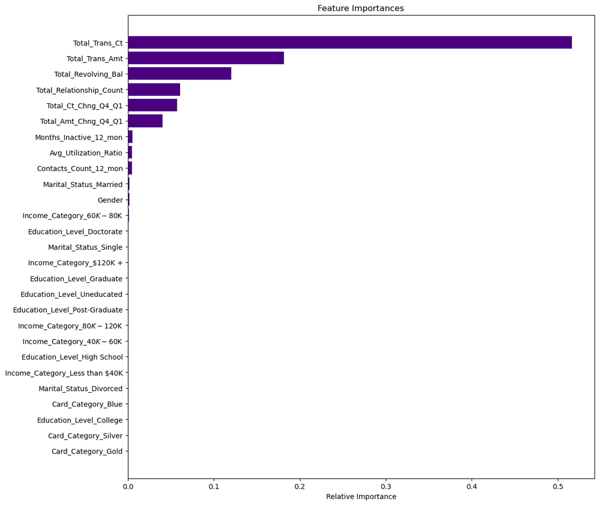

```python
#analyse feature importances of gboost_down
feature_names = X_train.columns
importances = gboost_down.feature_importances_
indices = np.argsort(importances)

plt.figure(figsize=(12, 12))
plt.title("Feature Importances")
plt.barh(range(len(indices)), importances[indices], color="indigo", align="center")
plt.yticks(range(len(indices)), [feature_names[i] for i in indices])
plt.xlabel("Relative Importance")
plt.show()
```

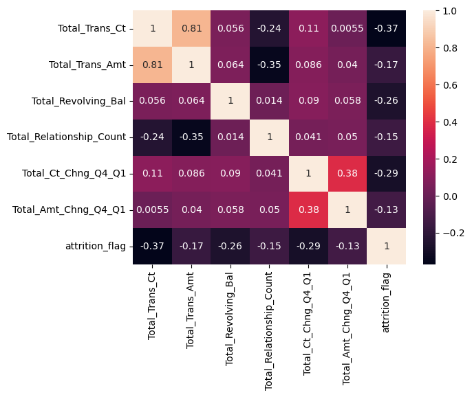

```python
sns.heatmap(data=df_heat[['Total_Trans_Ct', 'Total_Trans_Amt', 'Total_Revolving_Bal',
            'Total_Relationship_Count', 'Total_Ct_Chng_Q4_Q1', 'Total_Amt_Chng_Q4_Q1', 'attrition_flag']].corr(), annot=True)
```

### Insights

- *The features that are most* *critical** to the model are **Total_Trans_Ct, Total_Trans_Amt, Total_Revolving_Bal, Total_Relationship_Count, Total_Ct_Chng_Q4_Q1, Total_Amt_Chng_Q4_Q1***
- ***All the key features** that influence the model **have a negative correlation with attrition flag**. The lower the values of these features for a customer, the higher the chance of attrition*
- *The* *attrition of customers does not depend much on demographics, education, income category and card category**. It is mostly* *dependent on the quality of relationship** with the bank*

### Recommendations

- *Bank should* *focus on schemes and offers on the credit cards** that make them use the card more often. **Cashbacks, reward or loyalty points, privileged access etc**., can help customrs **engage more** with the credit cards.*
- *Bank should look into* *customisable products** so that it can **increase the relationship count**. This an **help customer spend categorisation and they may use different cards based on benefits***
- *Bank should* *periodically revise the credit limit** so that **customer can purchase big ticket items***
- *Bank should look into* *easy debt repayment options, provide longer time for due date etc.,***
- *Bank can look into offerings that* *increases the volume of small purchases** or **provide more rewards on big purchases**. Depending on the customer, both can **increase the relationship quality***
- *Bank should* *cross sell internal product tieups with credit card** to maintain healthy relationship count*